# Common pitfalls

Colin Gillespie ([@csgillespie](https://twitter.com/csgillespie))

Jumping Rivers Ltd ([@jumping_uk](https://twitter.com/jumping_uk))

## Common pitfalls

- The benefit of using R is that coding time is greatly reduced.
- But it’s very easy to write programs that are incredibly slow.

[figure not shown]

# Object growth

## Object growth: method 1

**Method 1** creates an empty vector, and grows the object:

```r
n = 100000
myvec = NULL; myvec = c()
for(i in 1:n)
    myvec = c(myvec, i)
```

## Object growth: method 2

Create an object of the final length and then changes the values in the object by subscripting:

```r
myvec = numeric(n)
for(i in 1:n)
    myvec[i] = i
```

## Object growth: method 3

Directly creates the final object:

```r
myvec = 1:n
```

## Object growth: timings

| $n$ | 1 | 2 | 3 |
| --- | --- | --- | --- |
| $10^5$ | 0.208 | 0.024 | 0.000 |
| $10^6$ | 25.50 | 0.220 | 0.000 |
| $10^7$ | 3827.0 | 2.212 | 0.000 |

## Object growth: timings

[figure not shown]

## Object growth

Object growth can be quite insidious since it is easy to hide growing objects in your code. For example:

```r
hit = NULL
for(i in 1:n) {
    if(runif(1) < 0.3)
        hit[i]  = TRUE
    else
        hit[i]  = FALSE
}
```

**Exercise** Rewrite the above code to avoid object growth

## Avoid rbind too!

A more common - and possibly more dangerous - problem is with `rbind`:

```r
df1 = data.frame(a = character(0), b = numeric(0))
for(i in 1:n)
    df1 = rbind(df1,
            data.frame(a = sample(letters, 1), b = runif(1)))
```

- Probably the main reason this is more common is because it is more likely that each iteration will have a different number of observations.
- However, a reasonable upper bound on the size of the final object is often known.
  - So pre-allocate!

## Rule 1

[figure not shown]

# Vectorise

## Vectorise

When writing code in R, you need to remember that you are using R and not C (or even F77!). For example,

```r
x = runif(1000) + 1
logsum = 0
for(i in 1:length(x))
    logsum = logsum + log(x[i])
```

This is a piece R code that has a strong, unhealthy influence from C.

## Vectorise

Instead, we should write

```r
logsum = sum(log(x))
```

- It’s faster. When $n = 10^7$ the ``R way’’ is about forty times faster.
- It’s neater.
- It doesn’t contain a bug when is of length $0$.

## Vectorise

Another common example is subsetting a vector. When writing in C, we would have something like:

```r
x = rnorm(10)
ans = NULL
for(i in 1:length(x)) {
    if(x[i] < 0)
        ans = c(ans, x[i])
}
```

**Exercise**: Rewrite the above code in a vectorised format

## Example: Monte-Carlo integration

It’s also important to make full use of R functions that use vectors. For example, suppose we wish to estimate
$$\int_0^1 x^2 dx$$
using a basic Monte-Carlo method.

## Example: Monte-Carlo integration

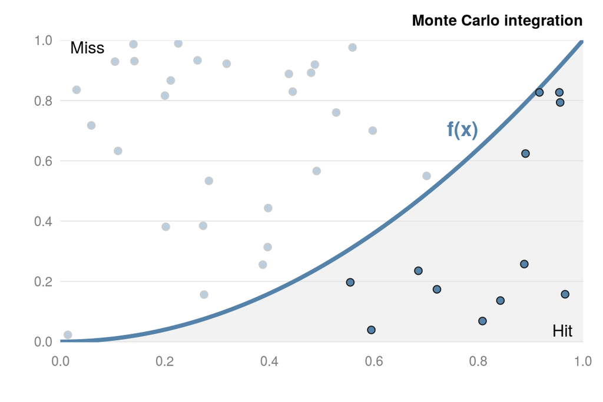

## Monte Carlo Integration

- Initialise: `hits = 0`
- **for** `i` in `1:N`
  - Generate two random numbers, $U_1, U_2$, between 0 and 1
  - If $U_2 < U_1^2$, then `hits = hits + 1`
- **end for**
- Area estimate = `hits/N`.

## Example: Monte-Carlo integration

```r
N = 500000
f = function(N){
    hits = 0
    for(i in 1:N)  {
        u1 = runif(1); u2 = runif(1)
        if(u1^2 > u2)
            hits = hits + 1
    }
    return(hits/N)
}
```

Which in R takes a few seconds:

```r
system.time(f(N))
```

```
##    user  system elapsed
##   1.888   0.000   1.888
```

## Example: Monte-Carlo integration

```r
N = 500000
f = function(N){
    hits = 0
    for(i in 1:N)  {
        u1 = runif(1); u2 = runif(1)
        if(u1^2 > u2)
            hits = hits + 1
    }
    return(hits/N)
}
```

**Exercise**: Can you vectorise the above code?

[figure not shown]

## If you can’t vectorise

Put any object creation outside the loop. For example

```r
jitter = function(x, k) rnorm(1, x, k)
parts = rnorm(10)
post = numeric(length(parts))
```

```r
for(i in 1:length(parts)){
    k = 1.06*sd(parts)/length(parts)
    post[i] = jitter(parts[i], k)
}
```

## If you can’t vectorise

Can be rewritten as

```r
k = 1.06*sd(parts)/length(parts)
for(i in 1:length(parts))
    post[i] = jitter(parts[i], k)
```

## Exercises 1 & 2

```r
vignette("common", package = "efficientTutorial")
```